# Ensemble Techniques Alt. project-Parkinson’s Diagnosis

# 6- HNR

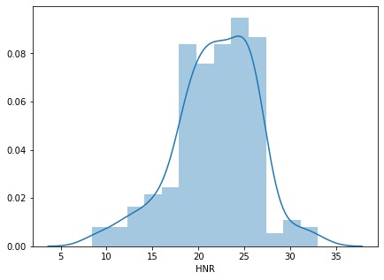

```python
# check out for the natural distribution of the variable

plt.figure(figsize = (7,5))
sns.distplot(data5['HNR'])
```

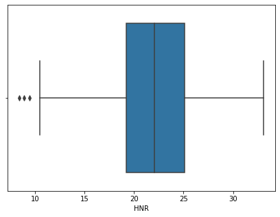

```python
# Scanning for the outliers by boxplot graph

plt.figure(figsize = (7,5))
sns.boxplot(data5['HNR'])
```

we can see there are few outliers below the lower whisker

```python
# find the outliers values and locations

Q1 = data5['HNR'].quantile(0.25)
Q3 = data5['HNR'].quantile(0.75)
IQR = Q3 - Q1
print('Q1=',Q1,',','Q3=',Q3,',','IQR=',IQR)
rows=np.where((data5['HNR']<(Q1 - 1.5 * IQR))|(data5['HNR']>(Q3 + 1.5 * IQR)))
outlayers=data5['NHR'].iloc[rows].sort_values()
print('outliers Rows:','\n',outlayers)
```

```
Q1= 19.198 , Q3= 25.075499999999998 , IQR= 5.877499999999998
outliers Rows:
 100   0.06
151   0.06
152   0.06
Name: NHR, dtype: float64
```

```python
# Dealing with 3 outliers by replacing with the IQR Score

data6 = data5.copy() # keep the original dataset intact

# Replace every outlier on the lower side by the lower whisker
for i in np.where(data6['HNR'] < Q1 - 1.5 * IQR):

    whisker  = Q1 - 1.5 * IQR
    data6['HNR'].iloc[i] = whisker

data6.iloc[rows]
```

|  | MDVP:Fo(Hz) | MDVP:Fhi(Hz) | MDVP:Flo(Hz) | MDVP:Jitter(%) | MDVP:Shimmer | NHR | HNR | status | RPDE | DFA | spread1 | spread2 | D2 |
| --- | --- | --- | --- | --- | --- | --- | --- | --- | --- | --- | --- | --- | --- |
| 100 | 125.64 | 141.07 | 116.35 | 0.01 | 0.07 | 0.06 | 10.38 | 1 | 0.67 | 0.66 | -3.70 | 0.26 | 2.99 |
| 151 | 192.82 | 224.43 | 168.79 | 0.01 | 0.07 | 0.06 | 10.38 | 1 | 0.63 | 0.77 | -2.43 | 0.45 | 3.08 |
| 152 | 198.12 | 233.10 | 174.48 | 0.01 | 0.07 | 0.06 | 10.38 | 1 | 0.58 | 0.75 | -2.84 | 0.36 | 3.18 |

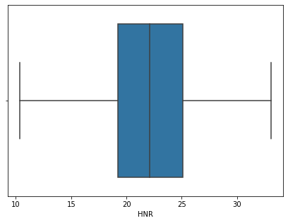

```python
# Checking out again for the outliers

plt.figure(figsize = (7,5))
sns.boxplot(data6['HNR'])
```

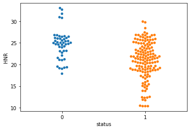

```python
# HNR vs the target 'status'

sns.swarmplot(x='status',y='HNR',data=data6)
plt.show()
```

```python
data6.columns
```

```
Index(['MDVP:Fo(Hz)', 'MDVP:Fhi(Hz)', 'MDVP:Flo(Hz)', 'MDVP:Jitter(%)',
       'MDVP:Shimmer', 'NHR', 'HNR', 'status', 'RPDE', 'DFA', 'spread1',
       'spread2', 'D2'],
      dtype='object')
```

# 7- RPDE

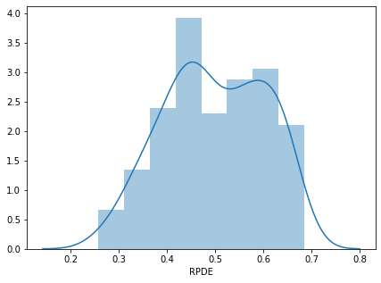

```python
# check out for the natural distribution of the variable

plt.figure(figsize = (7,5))
sns.distplot(data6['RPDE'])
```

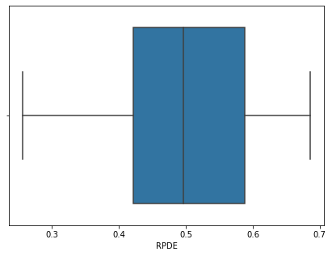

```python
# Scanning for the outliers by boxplot graph

plt.figure(figsize = (7,5))
sns.boxplot(data6['RPDE'])
```

we can't see any ouliers

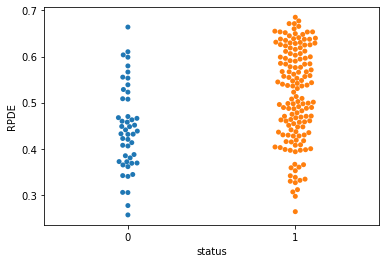

```python
# RPDE vs the target 'status'

sns.swarmplot(x='status',y='RPDE',data=data6)
plt.show()
```

number of PD cases increase when RPDE increases.

```python
data6.columns
```

```
Index(['MDVP:Fo(Hz)', 'MDVP:Fhi(Hz)', 'MDVP:Flo(Hz)', 'MDVP:Jitter(%)',
       'MDVP:Shimmer', 'NHR', 'HNR', 'status', 'RPDE', 'DFA', 'spread1',
       'spread2', 'D2'],
      dtype='object')
```

# 8- DFA

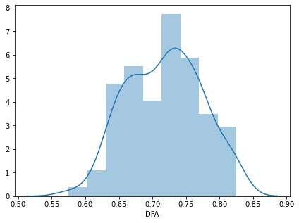

```python
# check out for the natural distribution of the variable

plt.figure(figsize = (7,5))
sns.distplot(data6['DFA'])
```

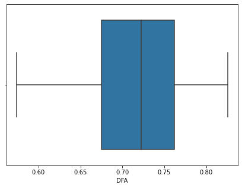

```python
# Scanning for the outliers by boxplot graph

plt.figure(figsize = (7,5))
sns.boxplot(data6['DFA'])
```

we can't see any ouliers

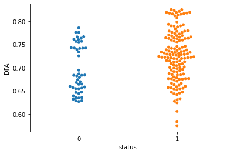

```python
# DFA vs the target 'status'

sns.swarmplot(x='status',y='DFA',data=data6)
plt.show()
```

number of PD cases increase when DFA increases.

```python
data6.columns
```

```
Index(['MDVP:Fo(Hz)', 'MDVP:Fhi(Hz)', 'MDVP:Flo(Hz)', 'MDVP:Jitter(%)',
       'MDVP:Shimmer', 'NHR', 'HNR', 'status', 'RPDE', 'DFA', 'spread1',
       'spread2', 'D2'],
      dtype='object')
```

# 9- spread1

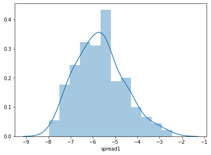

```python
# check out for the natural distribution of the variable

plt.figure(figsize = (7,5))
sns.distplot(data6['spread1'])
```

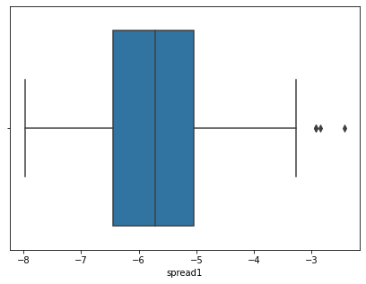

```python
# Scanning for the outliers by boxplot graph

plt.figure(figsize = (7,5))
sns.boxplot(data6['spread1'])
```

we can see few outliers beyond the upper whisker

```python
# find the outliers values and locations

Q1 = data6['spread1'].quantile(0.25)
Q3 = data6['spread1'].quantile(0.75)
IQR = Q3 - Q1
print('Q1=',Q1,',','Q3=',Q3,',','IQR=',IQR)
rows=np.where((data6['spread1']<(Q1 - 1.5 * IQR))|(data6['spread1']>(Q3 + 1.5 * IQR)))
outlayers=data6['spread1'].iloc[rows].sort_values()
print('outliers Rows:','spread1\n',outlayers)
```

```
Q1= -6.450096 , Q3= -5.046192 , IQR= 1.4039040000000007
outliers Rows: spread1
 17    -2.93
164   -2.93
152   -2.84
151   -2.43
Name: spread1, dtype: float64
```

```python
# Dealing with the 4 outliers by replacing with the IQR Score

data7 = data6.copy() # keep the original dataset intact

#Replace every outlier on the upper side by the upper whisker
for i in np.where(data7['spread1'] > Q3 + 1.5 * IQR):

    whisker  = Q3 + 1.5 * IQR
    data7['spread1'].iloc[i] = whisker

data7.iloc[rows]
```

|  | MDVP:Fo(Hz) | MDVP:Fhi(Hz) | MDVP:Flo(Hz) | MDVP:Jitter(%) | MDVP:Shimmer | NHR | HNR | status | RPDE | DFA | spread1 | spread2 | D2 |
| --- | --- | --- | --- | --- | --- | --- | --- | --- | --- | --- | --- | --- | --- |
| 17 | 168.78 | 232.18 | 75.60 | 0.01 | 0.03 | 0.03 | 20.38 | 1 | 0.63 | 0.61 | -2.94 | 0.43 | 3.01 |
| 151 | 192.82 | 224.43 | 168.79 | 0.01 | 0.07 | 0.06 | 10.38 | 1 | 0.63 | 0.77 | -2.94 | 0.45 | 3.08 |
| 152 | 198.12 | 233.10 | 174.48 | 0.01 | 0.07 | 0.06 | 10.38 | 1 | 0.58 | 0.75 | -2.94 | 0.36 | 3.18 |
| 164 | 102.27 | 142.83 | 85.90 | 0.01 | 0.03 | 0.04 | 18.45 | 1 | 0.67 | 0.67 | -2.94 | 0.40 | 2.56 |

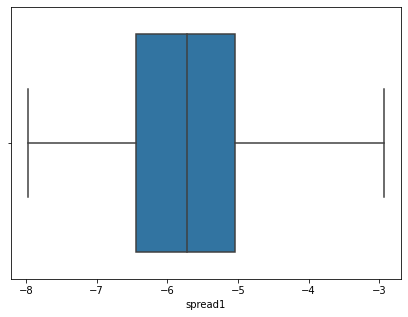

```python
# Checking out again for the outliers

plt.figure(figsize = (7,5))
sns.boxplot(data7['spread1'])
```

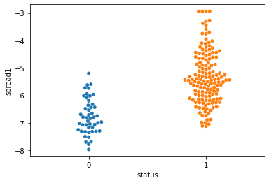

```python
# spread1 vs the target 'status'

sns.swarmplot(x='status',y='spread1',data=data7)
plt.show()
```

from the plot, the PD cases increase with the increasing of 'spread1' untill reach the point -5.5 then start going down.

```python
data7.columns
```

```
Index(['MDVP:Fo(Hz)', 'MDVP:Fhi(Hz)', 'MDVP:Flo(Hz)', 'MDVP:Jitter(%)',
       'MDVP:Shimmer', 'NHR', 'HNR', 'status', 'RPDE', 'DFA', 'spread1',
       'spread2', 'D2'],
      dtype='object')
```

# 10- spread2

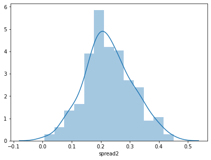

```python
# check out for the natural distribution of the variable

plt.figure(figsize = (7,5))
sns.distplot(data7['spread2'])
```

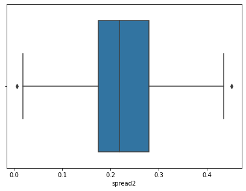

```python
# Scanning for the outliers by boxplot graph

plt.figure(figsize = (7,5))
sns.boxplot(data7['spread2'])
```

we can see 1 outlier below the lower whisker and 1 outlier beyond the upper whisker.

```python
# find the outliers values and locations

Q1 = data7['spread2'].quantile(0.25)
Q3 = data7['spread2'].quantile(0.75)
IQR = Q3 - Q1
print('Q1=',Q1,',','Q3=',Q3,',','IQR=',IQR)
rows=np.where((data7['spread2']<(Q1 - 1.5 * IQR))|(data7['spread2']>(Q3 + 1.5 * IQR)))
outlayers=data7['spread2'].iloc[rows].sort_values()
print('outliers Rows:','\n',outlayers)
```

```
Q1= 0.17435050000000002 , Q3= 0.279234 , IQR= 0.10488349999999996
outliers Rows:
 65    0.01
151   0.45
Name: spread2, dtype: float64
```

```python
# Dealing with the 2 outliers by replacing with the IQR Score

data8 = data7.copy() # keep the original dataset intact

#Replace every outlier on the upper side by the upper whisker
for i in np.where(data8['spread2'] > Q3 + 1.5 * IQR):

    whisker  = Q3 + 1.5 * IQR
    data8['spread2'].iloc[i] = whisker


# Replace every outlier on the lower side by the lower whisker
for i in np.where(data8['spread2'] < Q1 - 1.5 * IQR):

    whisker  = Q1 - 1.5 * IQR
    data8['spread2'].iloc[i] = whisker

data8.iloc[rows]
```

|  | MDVP:Fo(Hz) | MDVP:Fhi(Hz) | MDVP:Flo(Hz) | MDVP:Jitter(%) | MDVP:Shimmer | NHR | HNR | status | RPDE | DFA | spread1 | spread2 | D2 |
| --- | --- | --- | --- | --- | --- | --- | --- | --- | --- | --- | --- | --- | --- |
| 65 | 228.97 | 239.54 | 113.20 | 0.00 | 0.02 | 0.00 | 24.55 | 0 | 0.31 | 0.68 | -7.31 | 0.02 | 2.12 |
| 151 | 192.82 | 224.43 | 168.79 | 0.01 | 0.07 | 0.06 | 10.38 | 1 | 0.63 | 0.77 | -2.94 | 0.44 | 3.08 |

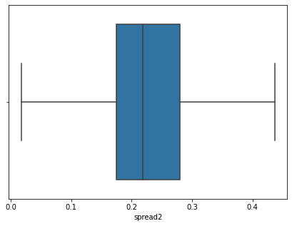

```python
# Checking out again for the outliers

plt.figure(figsize = (7,5))
sns.boxplot(data8['spread2'])
```

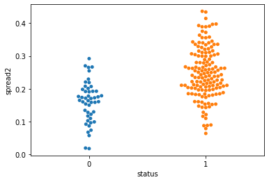

```python
# spread2 vs the target 'status'

sns.swarmplot(x='status',y='spread2',data=data8)
plt.show()
```

from the plot, the PD cases increase with the increasing of 'spread2'

```python
data8.columns
```

```
Index(['MDVP:Fo(Hz)', 'MDVP:Fhi(Hz)', 'MDVP:Flo(Hz)', 'MDVP:Jitter(%)',
       'MDVP:Shimmer', 'NHR', 'HNR', 'status', 'RPDE', 'DFA', 'spread1',
       'spread2', 'D2'],
      dtype='object')
```

# 11- D2

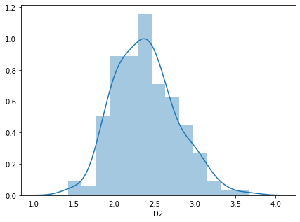

```python
# check out for the natural distribution of the variable

plt.figure(figsize = (7,5))
sns.distplot(data8['D2'])
```

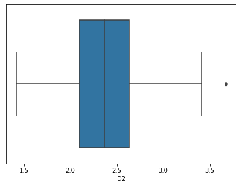

```python
# Scanning for the outliers by boxplot graph

plt.figure(figsize = (7,5))
sns.boxplot(data8['D2'])
```

we can see only 1 outlier beyond the upper whisker

```python
# find the outliers values and locations

Q1 = data8['D2'].quantile(0.25)
Q3 = data8['D2'].quantile(0.75)
IQR = Q3 - Q1
print('Q1=',Q1,',','Q3=',Q3,',','IQR=',IQR)
rows=np.where((data8['D2']<(Q1 - 1.5 * IQR))|(data8['D2']>(Q3 + 1.5 * IQR)))
outlayers=data8['D2'].iloc[rows].sort_values()
print('outliers Rows:','\n',outlayers)
```

```
Q1= 2.0991255 , Q3= 2.636456 , IQR= 0.5373304999999999
outliers Rows:
 89   3.67
Name: D2, dtype: float64
```

```python
# Dealing with outlier by replacing with the IQR Score

data9 = data8.copy() # keep the original dataset intact

#Replace every outlier on the upper side by the upper whisker
for i in np.where(data9['D2'] > Q3 + 1.5 * IQR):

    whisker  = Q3 + 1.5 * IQR
    data9['D2'].iloc[i] = whisker

data9.iloc[rows]
```

|  | MDVP:Fo(Hz) | MDVP:Fhi(Hz) | MDVP:Flo(Hz) | MDVP:Jitter(%) | MDVP:Shimmer | NHR | HNR | status | RPDE | DFA | spread1 | spread2 | D2 |
| --- | --- | --- | --- | --- | --- | --- | --- | --- | --- | --- | --- | --- | --- |
| 89 | 179.71 | 225.93 | 144.88 | 0.01 | 0.04 | 0.06 | 11.87 | 1 | 0.59 | 0.75 | -4.38 | 0.38 | 3.44 |

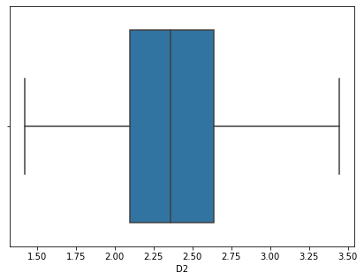

```python
# Checking out again for the outliers

plt.figure(figsize = (7,5))
sns.boxplot(data9['D2'])
```

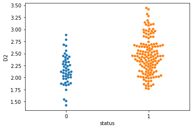

```python
# D2 vs the target 'status'

sns.swarmplot(x='status',y='D2',data=data9)
plt.show()
```

from the plot, the PD cases increase with the increasing of 'D2' untill reach the point 2.6 then start going down.

```python
dataP=data9.copy()
```

# splitting data

```python
x=dataP.drop(['status'],axis=1)
x.head()
```

|  | MDVP:Fo(Hz) | MDVP:Fhi(Hz) | MDVP:Flo(Hz) | MDVP:Jitter(%) | MDVP:Shimmer | NHR | HNR | RPDE | DFA | spread1 | spread2 | D2 |
| --- | --- | --- | --- | --- | --- | --- | --- | --- | --- | --- | --- | --- |
| 0 | 119.99 | 157.30 | 75.00 | 0.01 | 0.04 | 0.02 | 21.03 | 0.41 | 0.82 | -4.81 | 0.27 | 2.30 |
| 1 | 122.40 | 148.65 | 113.82 | 0.01 | 0.06 | 0.02 | 19.09 | 0.46 | 0.82 | -4.08 | 0.34 | 2.49 |
| 2 | 116.68 | 131.11 | 111.56 | 0.01 | 0.05 | 0.01 | 20.65 | 0.43 | 0.83 | -4.44 | 0.31 | 2.34 |
| 3 | 116.68 | 137.87 | 111.37 | 0.01 | 0.05 | 0.01 | 20.64 | 0.43 | 0.82 | -4.12 | 0.33 | 2.41 |
| 4 | 116.01 | 141.78 | 110.66 | 0.01 | 0.06 | 0.02 | 19.65 | 0.42 | 0.82 | -3.75 | 0.23 | 2.33 |

```python
y=dataP['status']
y.head()
```

```
0    1
1    1
2    1
3    1
4    1
Name: status, dtype: int64
```

```python
# import the train_test_split function, and then create training and testing variables and define the sizes.
from sklearn.model_selection import train_test_split
x_train,x_test,y_train,y_test=train_test_split(x,y,test_size=0.3,random_state=1)
```

```python
# create a record for the differnt ensemble models will be used in the cae study, to be compared later.

Algorithm=[]
train=[]
test=[]
recall=[]
precision=[]
roc=[]
```

```python
# import the  metrics functions to measure the performance of the models

from sklearn import metrics
from sklearn.metrics import recall_score, precision_score, accuracy_score, roc_auc_score
```

# I- Pruned Decision Tree-GINI

```
trn_sc= 94.12 %
tst_sc= 84.75 %
rcl_sc= 92.5 %
prc_sc= 86.05 %
roc_sc= 80.46 %
```

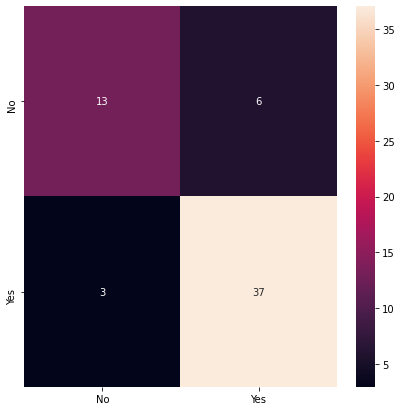

```python
from sklearn.tree import DecisionTreeClassifier

# Decision Tree Classifier using gini,

model=DecisionTreeClassifier(criterion='gini',random_state=1,max_depth=3,min_samples_leaf=5)
model.fit(x_train,y_train)
y_pred=model.predict(x_test)

trn_sc=model.score(x_train,y_train)
tst_sc=model.score(x_test,y_test)
rcl_sc=recall_score(y_test,y_pred)
prc_sc=precision_score(y_test,y_pred)
roc_sc=roc_auc_score(y_test,y_pred)

# Adding the values to the record
Algorithm.append('Decision Tree gini')
train.append(trn_sc)
test.append(tst_sc)
recall.append(rcl_sc)
precision.append(prc_sc)
roc.append(roc_sc)

print('trn_sc=',round(trn_sc*100,2),'%')
print('tst_sc=',round(tst_sc*100,2),'%')
print('rcl_sc=',round(rcl_sc*100,2),'%')
print('prc_sc=',round(prc_sc*100,2),'%')
print('roc_sc=',round(roc_sc*100,2),'%')

# Using confusion matrix graph to show the model's performance
cm=metrics.confusion_matrix(y_test, y_pred, labels=[0, 1])
df_cm = pd.DataFrame(cm, index = [i for i in ["No","Yes"]],
                         columns = [i for i in ["No","Yes"]])
plt.figure(figsize = (7,7))
sns.heatmap(df_cm, annot=True ,fmt='g');
```

# II- Pruned Decision Tree-Entropy

```
trn_sc= 96.32 %
tst_sc= 88.14 %
rcl_sc= 97.5 %
prc_sc= 86.67 %
roc_sc= 82.96 %
```

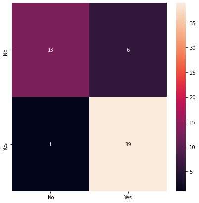

```python
# Decision Tree Classifier using gini,

model=DecisionTreeClassifier(criterion='entropy',random_state=1,max_depth=3,min_samples_leaf=5)
model.fit(x_train,y_train)
y_pred=model.predict(x_test)

trn_sc=model.score(x_train,y_train)
tst_sc=model.score(x_test,y_test)
rcl_sc=recall_score(y_test,y_pred)
prc_sc=precision_score(y_test,y_pred)
roc_sc=roc_auc_score(y_test,y_pred)

# Adding the values to the record
Algorithm.append('Decision Tree entropy')
train.append(trn_sc)
test.append(tst_sc)
recall.append(rcl_sc)
precision.append(prc_sc)
roc.append(roc_sc)

print('trn_sc=',round(trn_sc*100,2),'%')
print('tst_sc=',round(tst_sc*100,2),'%')
print('rcl_sc=',round(rcl_sc*100,2),'%')
print('prc_sc=',round(prc_sc*100,2),'%')
print('roc_sc=',round(roc_sc*100,2),'%')

# Using confusion matrix graph to show the model's performance
cm=metrics.confusion_matrix(y_test, y_pred, labels=[0, 1])
df_cm = pd.DataFrame(cm, index = [i for i in ["No","Yes"]],
                         columns = [i for i in ["No","Yes"]])
plt.figure(figsize = (7,7))
sns.heatmap(df_cm, annot=True ,fmt='g');
```

the Entropy model scored higher than the Gini one in all metrics.

# III- Random forest

```
trn_sc= 100.0 %
tst_sc= 89.83 %
rcl_sc= 100.0 %
prc_sc= 86.96 %
roc_sc= 84.21 %
```

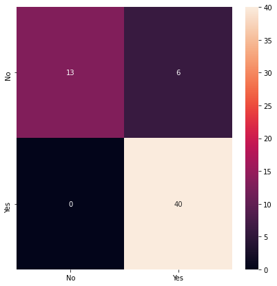

```python
from sklearn.ensemble import RandomForestClassifier
model=RandomForestClassifier(random_state=1,n_estimators=100)

model.fit(x_train,y_train)
y_pred=model.predict(x_test)

trn_sc=model.score(x_train,y_train)
tst_sc=model.score(x_test,y_test)
rcl_sc=recall_score(y_test,y_pred)
prc_sc=precision_score(y_test,y_pred)
roc_sc=roc_auc_score(y_test,y_pred)

# Adding the values to the record
Algorithm.append('Random Forest')
train.append(trn_sc)
test.append(tst_sc)
recall.append(rcl_sc)
precision.append(prc_sc)
roc.append(roc_sc)

print('trn_sc=',round(trn_sc*100,2),'%')
print('tst_sc=',round(tst_sc*100,2),'%')
print('rcl_sc=',round(rcl_sc*100,2),'%')
print('prc_sc=',round(prc_sc*100,2),'%')
print('roc_sc=',round(roc_sc*100,2),'%')

# Using confusion matrix graph to show the model's performance
cm=metrics.confusion_matrix(y_test, y_pred, labels=[0, 1])
df_cm = pd.DataFrame(cm, index = [i for i in ["No","Yes"]],
                         columns = [i for i in ["No","Yes"]])
plt.figure(figsize = (7,7))
sns.heatmap(df_cm, annot=True ,fmt='g');
```

# IV- Bagging

```
trn_sc= 99.26 %
tst_sc= 88.14 %
rcl_sc= 95.0 %
prc_sc= 88.37 %
roc_sc= 84.34 %
```

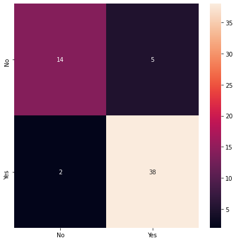

```python
from sklearn.ensemble import BaggingClassifier
model=BaggingClassifier(random_state=1,n_estimators=100,max_samples=.7,bootstrap=True)

model.fit(x_train,y_train)
y_pred=model.predict(x_test)

trn_sc=model.score(x_train,y_train)
tst_sc=model.score(x_test,y_test)
rcl_sc=recall_score(y_test,y_pred)
prc_sc=precision_score(y_test,y_pred)
roc_sc=roc_auc_score(y_test,y_pred)

# Adding the values to the record
Algorithm.append('Bagging')
train.append(trn_sc)
test.append(tst_sc)
recall.append(rcl_sc)
precision.append(prc_sc)
roc.append(roc_sc)

print('trn_sc=',round(trn_sc*100,2),'%')
print('tst_sc=',round(tst_sc*100,2),'%')
print('rcl_sc=',round(rcl_sc*100,2),'%')
print('prc_sc=',round(prc_sc*100,2),'%')
print('roc_sc=',round(roc_sc*100,2),'%')

# Using confusion matrix graph to show the model's performance
cm=metrics.confusion_matrix(y_test, y_pred, labels=[0, 1])
df_cm = pd.DataFrame(cm, index = [i for i in ["No","Yes"]],
                         columns = [i for i in ["No","Yes"]])
plt.figure(figsize = (7,7))
sns.heatmap(df_cm, annot=True ,fmt='g');
```

# V- AdaBoost

```
trn_sc= 99.26 %
tst_sc= 88.14 %
rcl_sc= 100.0 %
prc_sc= 85.11 %
roc_sc= 81.58 %
```

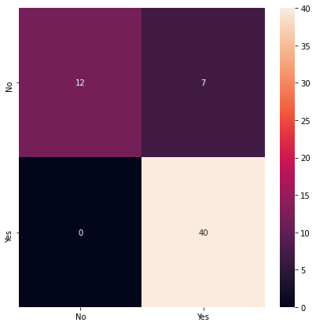

```python
from sklearn.ensemble import AdaBoostClassifier
model=AdaBoostClassifier(random_state=1,n_estimators=100,learning_rate=0.1)

model.fit(x_train,y_train)
y_pred=model.predict(x_test)

trn_sc=model.score(x_train,y_train)
tst_sc=model.score(x_test,y_test)
rcl_sc=recall_score(y_test,y_pred)
prc_sc=precision_score(y_test,y_pred)
roc_sc=roc_auc_score(y_test,y_pred)

# Adding the values to the record
Algorithm.append('AdaBoost')
train.append(trn_sc)
test.append(tst_sc)
recall.append(rcl_sc)
precision.append(prc_sc)
roc.append(roc_sc)

print('trn_sc=',round(trn_sc*100,2),'%')
print('tst_sc=',round(tst_sc*100,2),'%')
print('rcl_sc=',round(rcl_sc*100,2),'%')
print('prc_sc=',round(prc_sc*100,2),'%')
print('roc_sc=',round(roc_sc*100,2),'%')

# Using confusion matrix graph to show the model's performance
cm=metrics.confusion_matrix(y_test, y_pred, labels=[0, 1])
df_cm = pd.DataFrame(cm, index = [i for i in ["No","Yes"]],
                         columns = [i for i in ["No","Yes"]])
plt.figure(figsize = (7,7))
sns.heatmap(df_cm, annot=True ,fmt='g');
```

# VI- Gradient Boosting

```
trn_sc= 100.0 %
tst_sc= 84.75 %
rcl_sc= 95.0 %
prc_sc= 84.44 %
roc_sc= 79.08 %
```

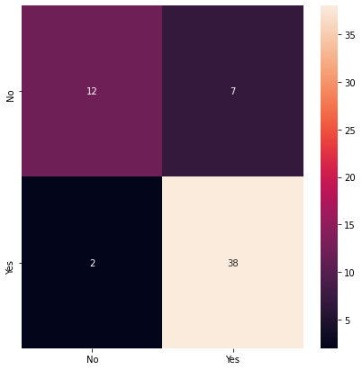

```python
from sklearn.ensemble import GradientBoostingClassifier
model=GradientBoostingClassifier(random_state=1,n_estimators=100)

model.fit(x_train,y_train)
y_pred=model.predict(x_test)

trn_sc=model.score(x_train,y_train)
tst_sc=model.score(x_test,y_test)
rcl_sc=recall_score(y_test,y_pred)
prc_sc=precision_score(y_test,y_pred)
roc_sc=roc_auc_score(y_test,y_pred)

# Adding the values to the record
Algorithm.append('Gradient Boosting')
train.append(trn_sc)
test.append(tst_sc)
recall.append(rcl_sc)
precision.append(prc_sc)
roc.append(roc_sc)

print('trn_sc=',round(trn_sc*100,2),'%')
print('tst_sc=',round(tst_sc*100,2),'%')
print('rcl_sc=',round(rcl_sc*100,2),'%')
print('prc_sc=',round(prc_sc*100,2),'%')
print('roc_sc=',round(roc_sc*100,2),'%')

# Using confusion matrix graph to show the model's performance
cm=metrics.confusion_matrix(y_test, y_pred, labels=[0, 1])
df_cm = pd.DataFrame(cm, index = [i for i in ["No","Yes"]],
                         columns = [i for i in ["No","Yes"]])
plt.figure(figsize = (7,7))
sns.heatmap(df_cm, annot=True ,fmt='g');
```

# Models Comparison

```python
# compare different models results:

results=pd.DataFrame()
results['Model']=Algorithm
results['Training Score']=train
results['Testing Score']=test
results['Recall']=recall
results['precision']=precision
results['ROC AUC Score']=roc
results=results.set_index('Model')
results.sort_values(by='Recall',ascending=False)
```

| Model | Training Score | Testing Score | Recall | precision | ROC AUC Score |
| --- | --- | --- | --- | --- | --- |
| Random Forest | 1.00 | 0.90 | 1.00 | 0.87 | 0.84 |
| AdaBoost | 0.99 | 0.88 | 1.00 | 0.85 | 0.82 |
| Decision Tree entropy | 0.96 | 0.88 | 0.97 | 0.87 | 0.83 |
| Bagging | 0.99 | 0.88 | 0.95 | 0.88 | 0.84 |
| Gradient Boosting | 1.00 | 0.85 | 0.95 | 0.84 | 0.79 |
| Decision Tree gini | 0.94 | 0.85 | 0.93 | 0.86 | 0.80 |

I'll choose 'Random Forest' model as the best classifier in this study as it has the highest Recall & Accuracy among all models